# Reproducible Research: Peer Assessment 1

```r
library("knitr")
library(ggplot2)
library(ggthemes)
library(dplyr)
library(lattice)
opts_chunk$set(fig.width=10, fig.height=5, fig.path ="figure/")
```

## Loading and preprocessing the data

```r
unprocesseddata <- read.csv(unz("activity.zip", "activity.csv"))
data_tbl=tbl_df(unprocesseddata[!is.na(unprocesseddata$steps),])
print(head(data_tbl))
```

```
## Source: local data frame [6 x 3]
##
##   steps       date interval
## 1     0 2012-10-02        0
## 2     0 2012-10-02        5
## 3     0 2012-10-02       10
## 4     0 2012-10-02       15
## 5     0 2012-10-02       20
## 6     0 2012-10-02       25
```

## What is mean total number of steps taken per day?

```
## Source: local data frame [53 x 2]
##
##          date totalsteps
## 1  2012-10-02        126
## 2  2012-10-03      11352
## 3  2012-10-04      12116
## 4  2012-10-05      13294
## 5  2012-10-06      15420
## 6  2012-10-07      11015
## 7  2012-10-09      12811
## 8  2012-10-10       9900
## 9  2012-10-11      10304
## 10 2012-10-12      17382
## ..        ...        ...
```

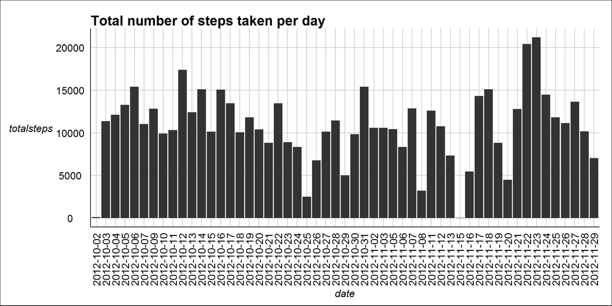

```r
#Calculate the total number of steps taken per day
data_tbl %>% group_by(date)  %>% summarise(totalsteps=sum(steps)) %>% print %>% ggplot(aes(date,totalsteps)) + geom_bar(stat = "identity") + ggtitle("Total number of steps taken per day") + theme_gdocs() + theme(axis.text.x = element_text(angle = 90, hjust = 1, vjust = 0.5))
```

```r
#Calculate and report the mean and median of the total number of steps taken per day
summarytable1=data_tbl %>% group_by(date)  %>% summarise(Entries_per_day=n(),totalsteps=sum(steps),totalsteps_mean=mean(steps),totalsteps_median=median(steps)) %>% print
```

```
## Source: local data frame [53 x 5]
##
##          date Entries_per_day totalsteps totalsteps_mean totalsteps_median
## 1  2012-10-02             288        126         0.43750                 0
## 2  2012-10-03             288      11352        39.41667                 0
## 3  2012-10-04             288      12116        42.06944                 0
## 4  2012-10-05             288      13294        46.15972                 0
## 5  2012-10-06             288      15420        53.54167                 0
## 6  2012-10-07             288      11015        38.24653                 0
## 7  2012-10-09             288      12811        44.48264                 0
## 8  2012-10-10             288       9900        34.37500                 0
## 9  2012-10-11             288      10304        35.77778                 0
## 10 2012-10-12             288      17382        60.35417                 0
## ..        ...             ...        ...             ...               ...
```

### As there is some confusion in the question about the mean and median total number of steps per day, I am reporting both options as table(see above) and as single values for mean and median(below)

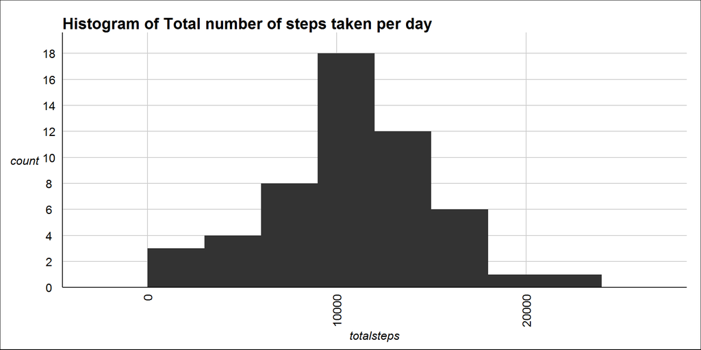

```r
ggplot(summarytable1,aes(totalsteps)) + geom_histogram(binwidth = 3000) + ggtitle("Histogram of Total number of steps taken per day")+ scale_y_discrete(breaks = seq(0,30,2))+ theme_gdocs() + theme(axis.text.x = element_text(angle = 90, hjust = 1, vjust = 0.5))
```

```r
#### Calculate and report the mean and median of the total number of steps taken per day
mean_of_totalsteps= as.integer(mean(summarytable1$totalsteps))
median_of_totalsteps= as.integer(median(summarytable1$totalsteps))
```

mean of totalsteps= 10766  
median of totalsteps= 10765

## What is the average daily activity pattern?

```r
#Which 5-minute interval, on average across all the days in the dataset, contains the maximum number of steps?
interval_tbl=data_tbl %>% group_by(interval) %>% summarise(AveragedSteps = mean(steps)) %>%
  print
```

```
## Source: local data frame [288 x 2]
##
##    interval AveragedSteps
## 1         0     1.7169811
## 2         5     0.3396226
## 3        10     0.1320755
## 4        15     0.1509434
## 5        20     0.0754717
## 6        25     2.0943396
## 7        30     0.5283019
## 8        35     0.8679245
## 9        40     0.0000000
## 10       45     1.4716981
## ..      ...           ...
```

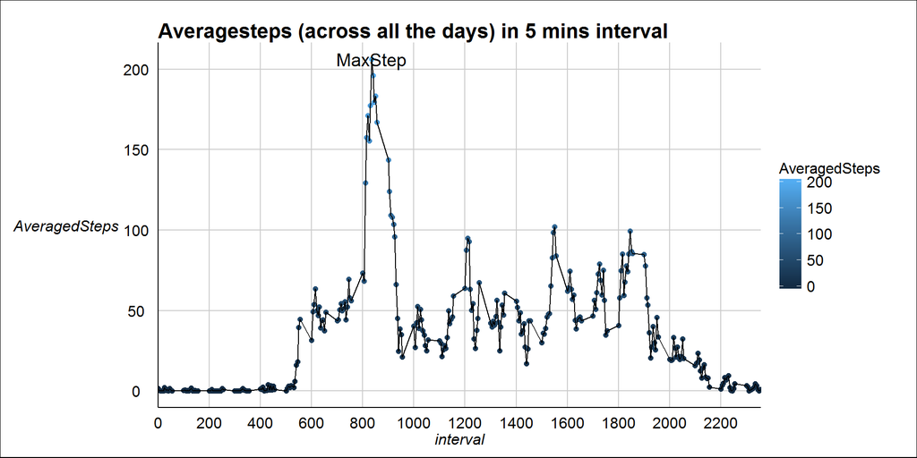

```r
interval_with_max_steps=interval_tbl[interval_tbl$AveragedSteps==max(interval_tbl$AveragedSteps),]

#Make a time series plot (i.e. type = "l") of the 5-minute interval (x-axis) and the average number of steps taken, averaged across all days (y-axis)

gg=ggplot(interval_tbl,aes(interval,AveragedSteps))
gg=gg + geom_point(aes(y=AveragedSteps,colour=AveragedSteps))
gg=gg + theme_gdocs() + geom_line(aes(y=AveragedSteps, group=1))
gg=gg + scale_x_discrete(breaks = seq(0, 2355, by = 200))
gg=gg + ggtitle("Averagesteps (across all the days) in 5 mins interval")
gg=gg +geom_text(data = interval_with_max_steps, aes(x = interval , y = AveragedSteps, label = "MaxStep"))
plot(gg)
```

#### Which 5-minute interval, on average across all the days in the dataset, contains the maximum number of steps? = 835, 206.1698113

## Imputing missing values

```r
#Calculate and report the total number of missing values in the dataset (i.e. the total number of #rows with NAs)

total_na_rows= nrow(unprocesseddata[is.na(unprocesseddata$steps),])
```

#### Total number of rows with NAs= 2304

#### Devise a strategy for filling in all of the missing values in the dataset. The strategy does not need to be sophisticated. For example, you could use the mean/median for that day, or the mean for that 5-minute interval, etc.

#### My strategy is to use the mean steps (across all days) in that interval .

```r
interval_mean_tbl=data_tbl %>% group_by(interval) %>% summarise(AveragedSteps=mean(steps))
interval_mean_tbl=interval_mean_tbl %>% mutate(AveragedSteps=floor(AveragedSteps))
ungroup(interval_mean_tbl)
```

```
## Source: local data frame [288 x 2]
##
##    interval AveragedSteps
## 1         0             1
## 2         5             0
## 3        10             0
## 4        15             0
## 5        20             0
## 6        25             2
## 7        30             0
## 8        35             0
## 9        40             0
## 10       45             1
## ..      ...           ...
```

```r
#Create a new dataset that is equal to the original dataset but with the missing data filled in.

newdata=left_join(unprocesseddata,interval_mean_tbl)
newdatafinal=newdata %>% mutate(newsteps=ifelse(is.na(newdata$steps),newdata$AveragedSteps,newdata$steps)) %>% select(newsteps,date,interval) %>%  rename(steps=newsteps)
rm(newdata)

print(head(newdatafinal))
```

```
##   steps       date interval
## 1     1 2012-10-01        0
## 2     0 2012-10-01        5
## 3     0 2012-10-01       10
## 4     0 2012-10-01       15
## 5     0 2012-10-01       20
## 6     2 2012-10-01       25
```

```r
#Make a histogram of the total number of steps taken each day and Calculate and report the mean and median total number of steps taken per day. Do these values differ from the estimates from the first part of the assignment? What is the impact of imputing missing data on the estimates of the total daily number of steps?

summarytable2=newdatafinal %>% group_by(date)  %>% summarise(Entries_per_day=n(),totalsteps=sum(steps),totalsteps_mean=mean(steps),totalsteps_median=median(steps)) %>% print
```

```
## Source: local data frame [61 x 5]
##
##          date Entries_per_day totalsteps totalsteps_mean totalsteps_median
## 1  2012-10-01             288      10641        36.94792              33.5
## 2  2012-10-02             288        126         0.43750               0.0
## 3  2012-10-03             288      11352        39.41667               0.0
## 4  2012-10-04             288      12116        42.06944               0.0
## 5  2012-10-05             288      13294        46.15972               0.0
## 6  2012-10-06             288      15420        53.54167               0.0
## 7  2012-10-07             288      11015        38.24653               0.0
## 8  2012-10-08             288      10641        36.94792              33.5
## 9  2012-10-09             288      12811        44.48264               0.0
## 10 2012-10-10             288       9900        34.37500               0.0
## ..        ...             ...        ...             ...               ...
```

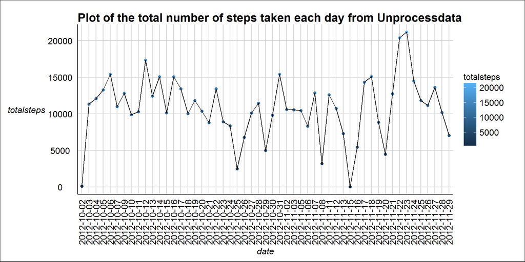

```r
ggU=ggplot(summarytable1,aes(date,totalsteps))+ geom_point(aes(y=totalsteps,colour=totalsteps))
ggU=ggU+theme_gdocs() +theme(axis.text.x=element_text(angle=-270))+ggtitle("Plot of the total number of steps taken each day from Unprocessdata ")
ggU=ggU + geom_line(aes(y=totalsteps, group=1))
plot(ggU)
```

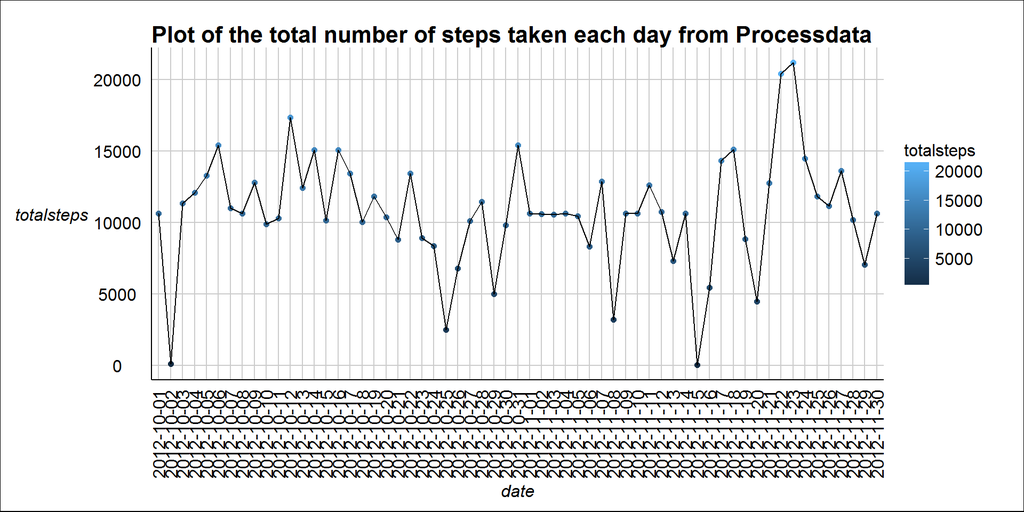

```r
ggP=ggplot(summarytable2,aes(date,totalsteps))+ geom_point(aes(y=totalsteps,colour=totalsteps))
ggP=ggP+theme_gdocs() +theme(axis.text.x=element_text(angle=-270))+ggtitle("Plot of the total number of steps taken each day from Processdata ")
ggP=ggP + geom_line(aes(y=totalsteps, group=1))
plot(ggP)
```

#### New dataset with with the missing data filled in is “newdatafinal”

#### So effect for imputing missing data is mainly on the (eg firstday/last day) days that had all the NAs. rest of the days did not show any significant effect. as clear from the graph

### same as mentioned earlier I am reporting the both options of total steps per day

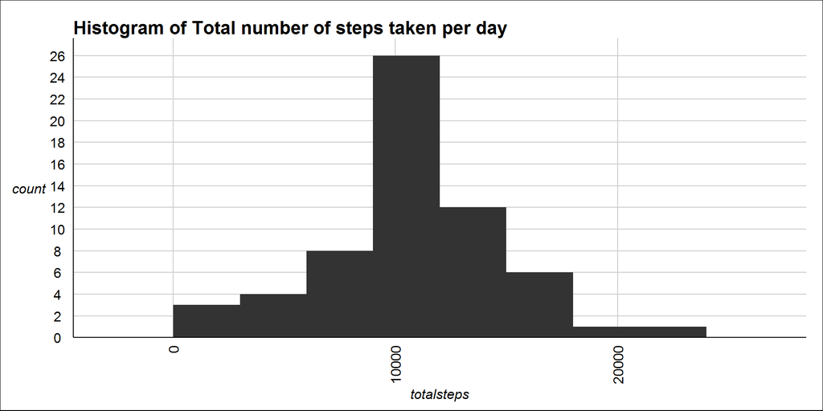

```r
ggplot(summarytable2,aes(totalsteps)) + geom_histogram(binwidth = 3000) + ggtitle("Histogram of Total number of steps taken per day")+ scale_y_discrete(breaks = seq(0,30,2))+ theme_gdocs() + theme(axis.text.x = element_text(angle = 90, hjust = 1, vjust = 0.5))
```

```r
#### Calculate and report the mean and median of the total number of steps taken per day after filling missing data
new_mean_of_totalsteps= as.integer(mean(summarytable2$totalsteps))
new_median_of_totalsteps= as.integer(median(summarytable2$totalsteps))
```

mean of totalsteps= 10749  
median of totalsteps= 10641

#### There is very slight change in mean and median after filling the missing data.

## Are there differences in activity patterns between weekdays and weekends?

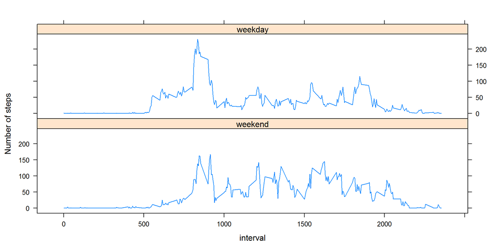

```r
weekdays <- c('Monday', 'Tuesday', 'Wednesday', 'Thursday', 'Friday')

newdatafinal$weekday <- factor((weekdays(as.Date(newdatafinal$date)) %in% weekdays),
         levels=c(FALSE, TRUE), labels=c('weekend', 'weekday'))

newdatafinal_summary= newdatafinal %>% group_by(weekday,interval) %>% summarise(steps =mean(steps))

xyplot( steps ~ interval | weekday , data=newdatafinal_summary, type="l",layout=c(1,2),xlab="interval",ylab="Number of steps")
```

#### There are some visible differences between weekdays and weeken activities.